# Hexagons, moths, and light - Full work flow.

### Oct 16, 2019, Lauren Chan

http://strimas.com/spatial/hexagonal-grids/

This is working for the most part, though cumbersome and for just play data. BUT, it has all the bits so that we can do what we need for future analyses...

Note: This analysis requires make_grid.r It's the second make_grid.r on the tutorial, but can be downloaded here as well: https://github.com/laurenchan/notebook/blob/master/citizen_sci/make_grid.r

It also requires the light layer which is about 750 MB and too big to post here, but which can be downloaded from here: https://pacificu.box.com/s/p46z3f267ewpmx9yru1no2n55tlzw2hy

```r
suppressMessages(library(dplyr))
library(tidyr)
library(sp)
suppressMessages(library(raster))
suppressMessages(library(rgeos))
library(rgbif)
suppressMessages(library(viridis))
suppressMessages(library(gridExtra))
library(rasterVis)
set.seed(1)
```

Save files to data/hex-grids. Make that path prior to running R code.

### Load USA map

Retrieve map using getData command which retrieves from the GADM database.

```r
study_area <- getData("GADM", country = "USA", level = 0, path="data/hex-grids") %>%
    disaggregate %>%
    geometry
```

Remove islands and clean up (this is from fishnet/hex tutorial. May not be appropriate for our study. Need to decide.

```r
study_area <- sapply(study_area@polygons, slot, "area") %>%
  {which(. == max(.))} %>%
  study_area[.]
```

Clipping the study area. I *think* this has to be done before projecting. Will need to make sure that it doesn't create strange artifacts.

```r
clip_list <- c(-80, -70, 35, 45)
study_area <- crop(study_area, clip_list)
```

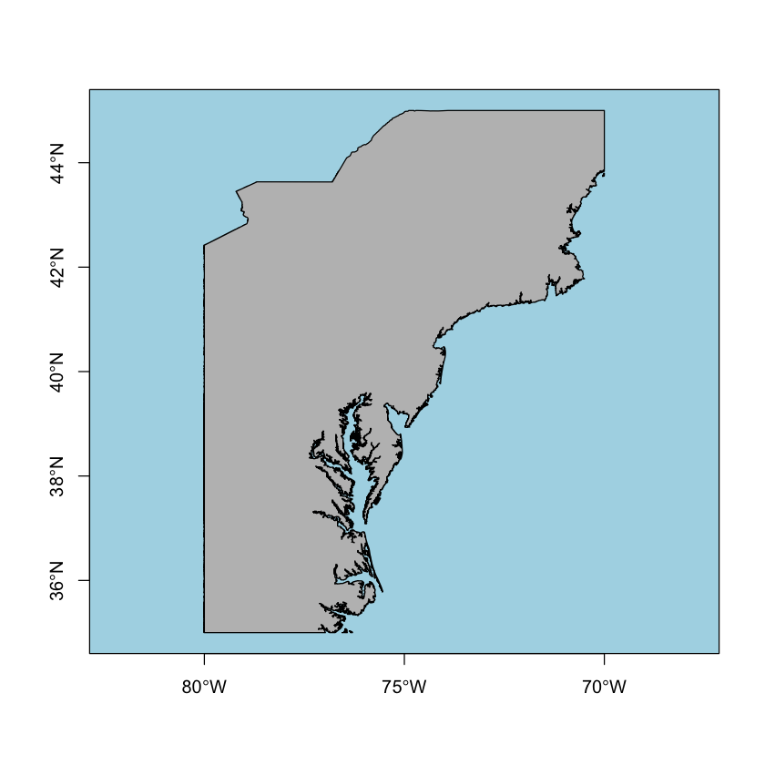

```r
plot(study_area, col="gray", bg="lightblue", axes=TRUE)
```

### Overlay hexagonal grids

```r
source("make_grid.r")
```

```r
study_area_utm <- CRS("+proj=utm +zone=14 +datum=WGS84 +units=km +no_defs") %>%
  spTransform(study_area, .)
```

Make the hex grid for the UTM study area. Cell area is in km. Need to be smart about the scale we are looking at relative to the resolution of the raster data and the biology of the organisms.

```r
hex_grid <- make_grid(study_area_utm, type = "hexagonal", cell_area = 625, clip = FALSE)
```

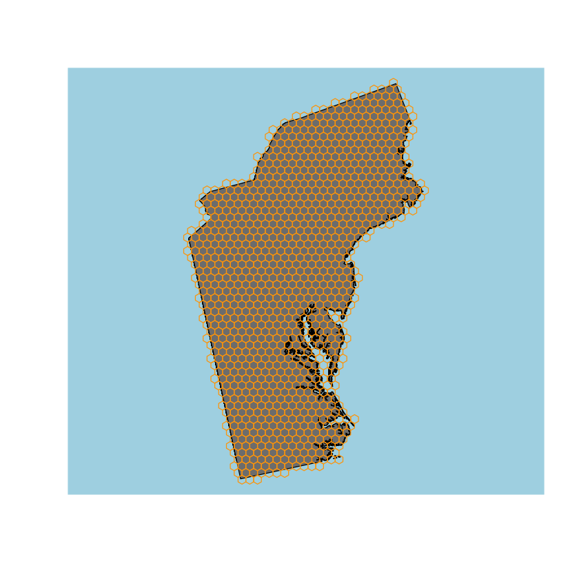

```r
plot(study_area_utm, col = "grey50", bg = "light blue", axes = FALSE)
plot(hex_grid, border = "orange", add = TRUE)
```

# Upload counts and localities and summarize for hex cells

Tested with eBird first

```r
library(rebird)
mykey <- "96h4mi8jusor"
```

```r
spName <- "Zonotrichia albicollis"
species <- species_code(spName)
```

```
White-throated Sparrow (Zonotrichia albicollis): whtspa
```

```r
sightings <- ebirdregion(loc = 'US', species = species, key=mykey)
names(sightings)
```

1. 'speciesCode'

2. 'comName'

3. 'sciName'

4. 'locId'

5. 'locName'

6. 'obsDt'

7. 'howMany'

8. 'lat'

9. 'lng'

10. 'obsValid'

11. 'obsReviewed'

12. 'locationPrivate'

Pull lng lat for the dataframe (you dont lose it... it's a data.frame thing). And, set the projection for the sightings dataframe.

```r
coordinates(sightings) <- ~ lng + lat
```

```r
projection(sightings) <- projection(study_area)
```

```r
sightings <- spTransform(sightings,
                          CRS("+proj=utm +zone=14 +datum=WGS84 +units=km +no_defs"))
```

```r
cropdf  <- crop(sightings, study_area_utm)
```

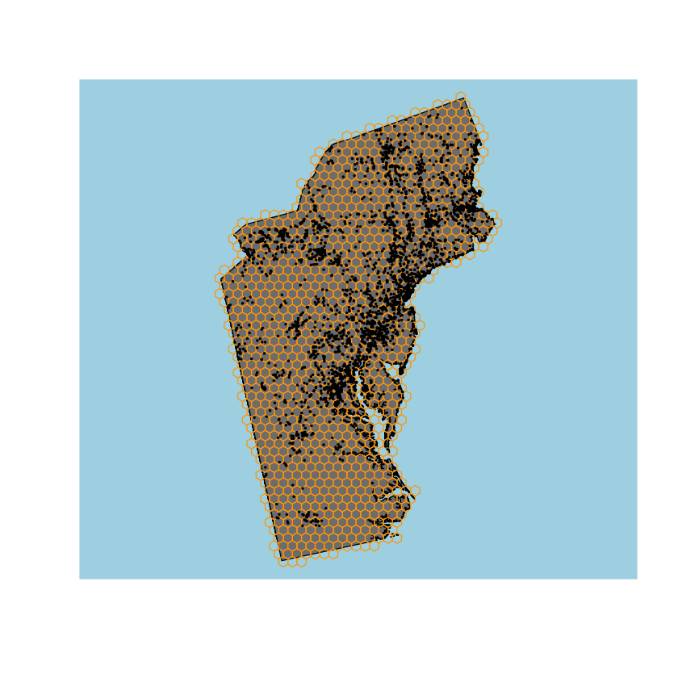

```r
plot(study_area_utm, col = "grey50", bg = "light blue", axes = FALSE)
plot(hex_grid, border = "orange", add = TRUE)
plot(cropdf, add=T, pch=19, cex=0.25)
```

### This is from fishnets and hex tutorial...

I don't totally understand what is happening here, but it is summing like we need it to. It would be nice to generalize this to do for several species at once...

```r
fill_missing <- expand.grid(id=row.names(hex_grid), stringsAsFactors=FALSE)
pt_density  <- over(hex_grid, cropdf, returnList=TRUE) %>%
    plyr::ldply(.fun = function(x) x, .id = "id") %>%
    mutate(id = as.character(id)) %>%
    count(id) %>%
    left_join(fill_missing, ., by = "id") %>%
    SpatialPolygonsDataFrame(hex_grid, .)

#alt
pt_den1 <- over(hex_grid, cropdf, returnList=TRUE)
```

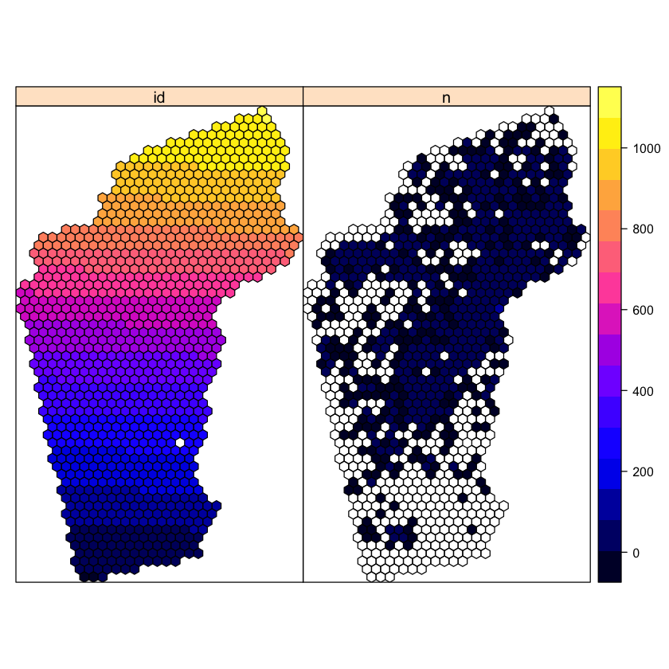

```r
spplot(pt_density)  #Not sure why both of these are plotting but not worrying about it for now.
```

# Load and plot the light data. Clip to the same as the study_area_utm

Downloaded from https://ngdc.noaa.gov/eog/dmsp/downloadV4composites.html (I think)

```r
r <- raster("~/Downloads/F182013.v4/F182013.v4c_web.avg_vis.tif")
r <- crop(r, clip_list)
```

```r
r <- projectRaster(r, to=raster(hex_grid, res=1))
```

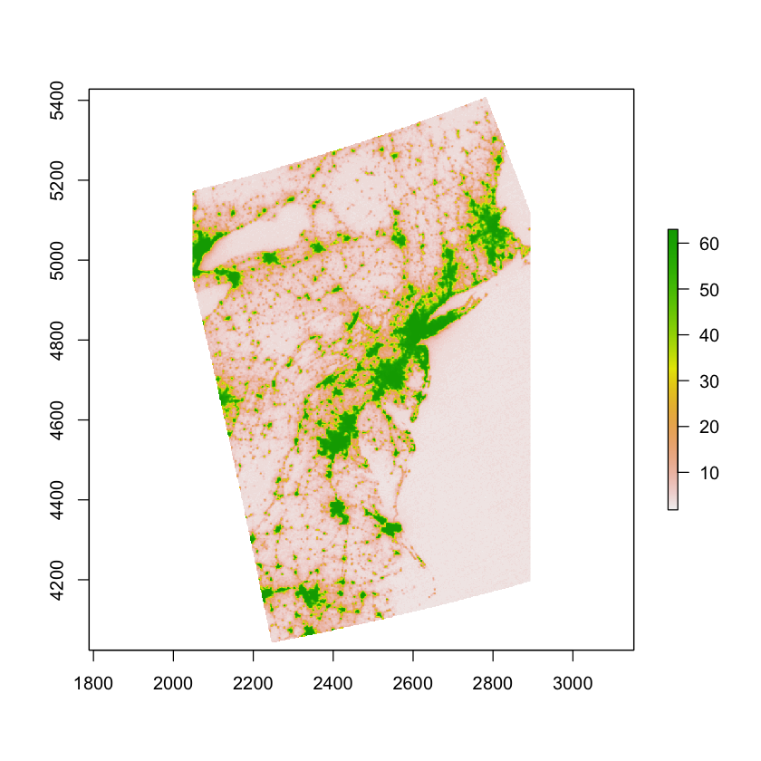

```r
plot(r)
```

```r
hex_light <- extract(r, hex_grid, fun=mean, na.rm=TRUE, sp=TRUE)
```

```r
class(hex_light)
```

'SpatialPolygonsDataFrame'

```r
hex_light.df <- as.data.frame(hex_light)
```

```r
p1 <- levelplot(r,
                col.regions = terrain.colors,
                margin = FALSE, scales = list(draw = FALSE),
                colorkey = list(
                  #space = "bottom",
                  at = seq(0, 60, length.out = 256),
                  labels = list(at = 10 * 0:6,
                                labels = format(10 * 0:6, big.mark = ","))
                )
      )

# Need to adjust sequence to get colors correct.
#For sums
#p2 <- spplot(hex_light,
#             col.regions = terrain.colors(256),
#             at = seq(0, 40000, length.out = 256),
#             colorkey = list(
#               labels = list(at = seq(0, 40000, 5000),
#                             labels = format(seq(0, 40000, 5000), big.mark = ","))
#             )
#      )

#For means
p2 <- spplot(hex_light,
             col.regions = terrain.colors(256),
             at = seq(0, 60, length.out = 256),
             colorkey = list(
               labels = list(at = 10 * 0:6,
                                labels = format(10 * 0:6, big.mark = ","))
             )
      )
```

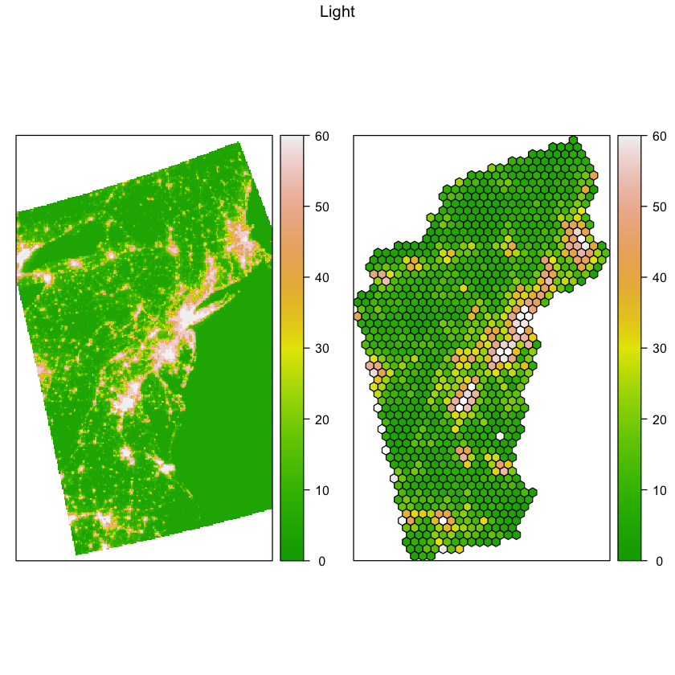

```r
grid.arrange(p1, p2, ncol = 2, top = "Light")
```